# Valores da produção de motociclos no País

Rayza Camila dos Santos Silva

2023-01-14

# Introdução

O banco de dados que será apresetado refere-se aos valores da produção de motociclos no País entre janeiro de 1993 à setembro de 2022,com suas variáveis data e valor(R$).Através desse banco de dados irei realizar uma análise de série temporal e apresentar o melhor modelo para previsão para os próximos passos(meses/anos).

# Pacotes necessários

```r
library(TSA)
library(forecast)
library(fpp3)
library(stringr)
library(readr)
```

# Entrando com o banco de dados

```r
dataset<-read_delim( "bcdata.sgs.1377.csv",
                    delim = ";", escape_double = FALSE, col_types = cols(data = col_date(format = "%d/%m/%Y")),   trim_ws = TRUE)
head(dataset)
```

```
## # A tibble: 6 × 2
##   data       valor
##   <date>     <dbl>
## 1 1993-01-01  4555
## 2 1993-02-01  5066
## 3 1993-03-01  6815
## 4 1993-04-01  5744
## 5 1993-05-01  6358
## 6 1993-06-01  7091
```

## Tratamento do banco de dados

```r
dados <- dataset %>%
  mutate( ano_mes = str_sub( data, 1, 7 )  ) %>%
  group_by(ano_mes) %>% summarise( producao = sum(valor)  )
dados
```

```
## # A tibble: 357 × 2
##    ano_mes producao
##    <chr>      <dbl>
##  1 1993-01     4555
##  2 1993-02     5066
##  3 1993-03     6815
##  4 1993-04     5744
##  5 1993-05     6358
##  6 1993-06     7091
##  7 1993-07     7518
##  8 1993-08     7970
##  9 1993-09    10242
## 10 1993-10     9049
## # … with 347 more rows
```

## transformando parao formato tstible

```r
serie <- dados %>%
  mutate(data = yearmonth(ano_mes))%>%
  as_tsibble(index= data )
serie
```

```
## # A tsibble: 357 x 3 [1M]
##    ano_mes producao     data
##    <chr>      <dbl>    <mth>
##  1 1993-01     4555 1993 Jan
##  2 1993-02     5066 1993 Feb
##  3 1993-03     6815 1993 Mar
##  4 1993-04     5744 1993 Apr
##  5 1993-05     6358 1993 May
##  6 1993-06     7091 1993 Jun
##  7 1993-07     7518 1993 Jul
##  8 1993-08     7970 1993 Aug
##  9 1993-09    10242 1993 Sep
## 10 1993-10     9049 1993 Oct
## # … with 347 more rows
```

```r
tail(serie)
```

```
## # A tsibble: 6 x 3 [1M]
##   ano_mes producao     data
##   <chr>      <dbl>    <mth>
## 1 2022-04   112678 2022 Apr
## 2 2022-05   129781 2022 May
## 3 2022-06   101695 2022 Jun
## 4 2022-07   104776 2022 Jul
## 5 2022-08   145852 2022 Aug
## 6 2022-09   139622 2022 Sep
```

## Análisando o comportamento da série

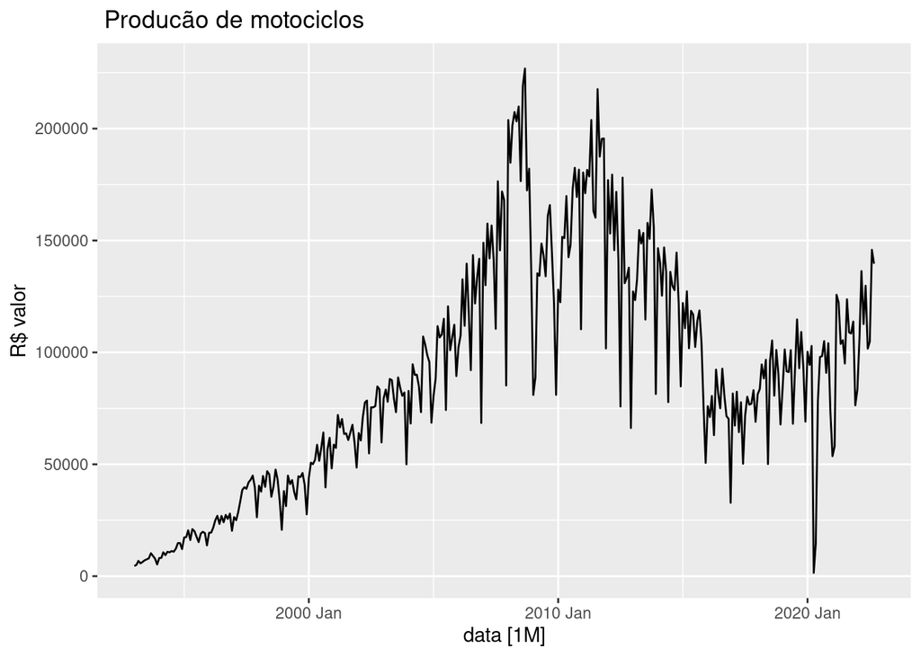

```r
plot_serie = serie %>%
  autoplot(producao) +
  labs(title=" Producão de motociclos ",
       y=" R$ valor ")
plot_serie
```

O gráfico apresenta não estacionariedade,pois,pode-se observar que o gráfico possui tendência e não tem sazonalidade.